# Homework 4 Süleyman Turancan Burucu

Süleyman Turancan Burucu

1/29/2021

# Stationarity Study and ARIMA Modeling of Hourly-Averaged Daily Electricity Consumption

## **1. Introduction and Stationarity Study**

> In brief, this work includes what is EPIAS, the meaning of stationarity, how to make the electricity consumption data stationary, and how to implement an ARIMA model for electricity consumption amounts together with two-week predictions.

To begin with, stationarity means that statistical properties of the process doesn’t change over time. Shortly, the mean, and the variance don’t change over time. Specifically for this model, the electricity consumption is analyzed in daily period by dividing the daily electricity consumption of Turkey to 24, in hourly basis.

As a whole, the electricity consumption traces a seasonal period which can be seen easily, it seems like sinusoidal wave. Sometimes this appearance is somehow corrupted due to possible reasons such as time of the day, being in a lockdown period, being in a weekday or not, being in summer or winter, etc. These reasons apparently can be increased. Thus, stationarity of the process can not be maintained.

To this variational respect, electricity production and distribution are a bit manipulative. In other words, if it is not regulated by some rules, then uncontrolled and volatile-pricing authorities can be sprung. Therefore, this manipulative disposition is precluded by EPIAS, which is the regulatory authority for energy market.

This variational nature of the electricity consumption, theoretical models are being produced in accordance with statistical knowledge and time series approaches. Also, modeling, to make forecasts, has become widespread and being used by so many energy production and distribution companies and also used for academical purposes. Modeling can be done by different modeling techniques. For this work, the ARIMA model is going to be examined after stationary is explained. When it comes to being stationary, we need to make sure that the data that we are going to make prediction for should be made stationary in order to get correct predictions. To start, the hourly and daily electricity consumption plot is given below:

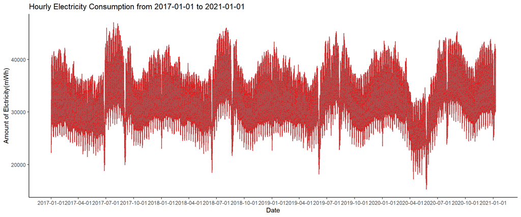

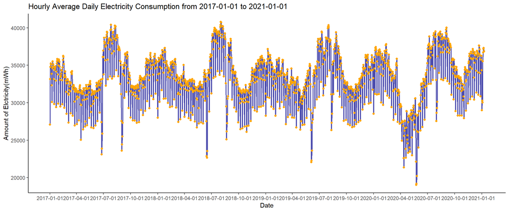

As you can see from the above, the electricity consumption data doesn’t seem stationary, due to seasonality. Also, we should check the autocorrelation for hourly and daily data (hourly data is also given in order to have a chance for looking in detail) to make sure that is there any seasonality or not. The first ACF and PACF plots are for hourly consumption and the last ACF and PACF plots are for daily consumption:

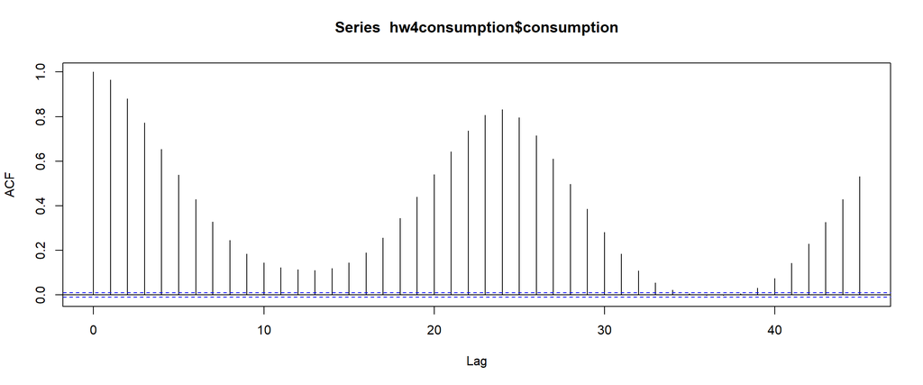

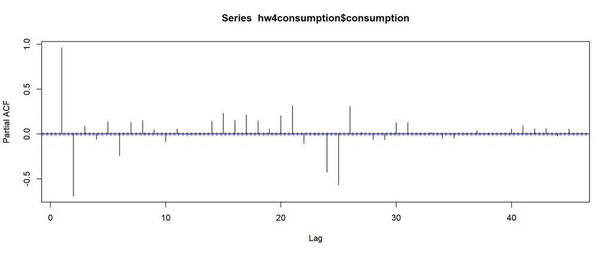

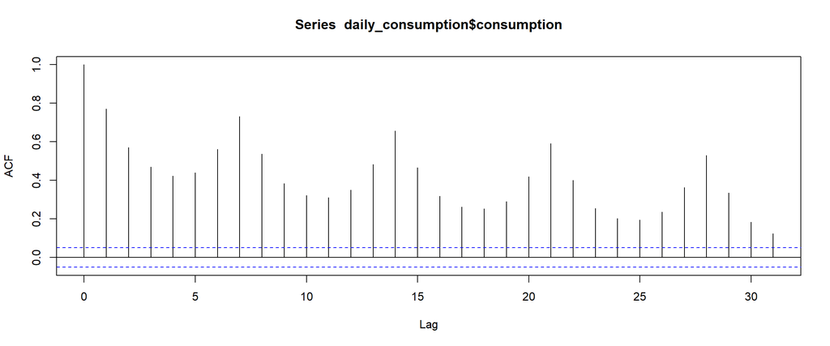

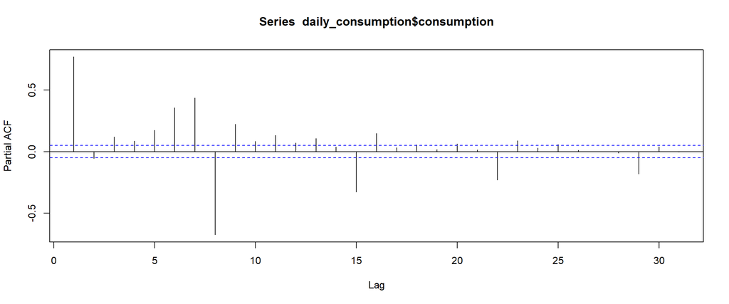

It can be seen that, even in daily data, there is asn obvious seasonality, which can be seen from the first ACF’s shape that seems like a wave. Also, there is significant autocorrelation at lag-24, due to nature of day which consists of 24 hour. Besides, the autocorrelation can be seen also at daily consumption’s ACF and PACF plots, ACF plot of which indicates significant autocorrelation at lag-7, due to the nature of week consisted of 7 days. Therefore, the daily consumption data should be made stationary. The first thing that we can do is differencing. For taking the difference, we must be sure that the data is not stationary. This sureness can also be provided by checking the KPSS Test’s results of related data by typing “summary(ur.kpss(related_data))” to the computer. That code shows that whether we need differencing or not. Though, we are sure that daily consumption is not stationary and we don’t need to check the results of the KPSS Test. Yet, this results are provided the below of the plots to make sure that whether the differenced data is stationary or not. Let’s try to make differencing lag-7 and check their ACF and PACF plots together with checking the differenced data’s plot since we can get weekly pattern at ACF and PACF at differenced data:

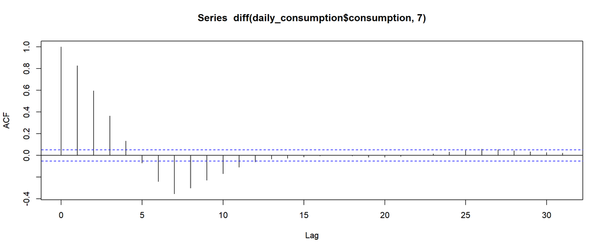

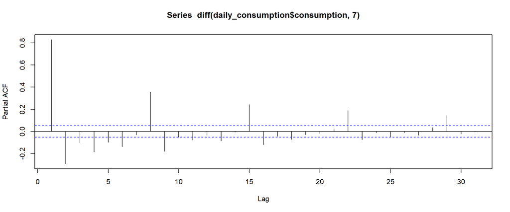

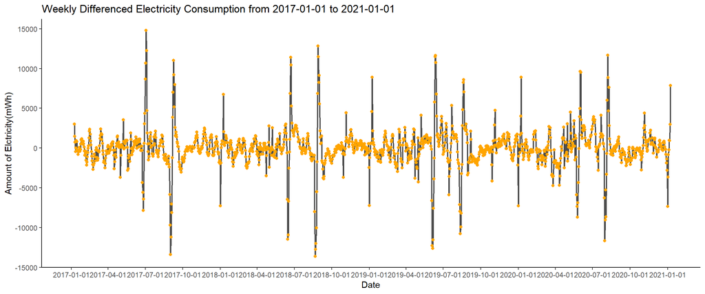

```
##
## #######################
## # KPSS Unit Root Test #
## #######################
##
## Test is of type: mu with 7 lags.
##
## Value of test-statistic is: 0.0121
##
## Critical value for a significance level of:
##                 10pct  5pct 2.5pct  1pct
## critical values 0.347 0.463  0.574 0.739
```

Let’s try to make differencing at lag-1 and check their ACF and PACF plots together with checking the differenced data’s plot since we can get 1-day lagged pattern at ACF and PACF at differenced data. Results of the KPSS Test are provided below of the plots:

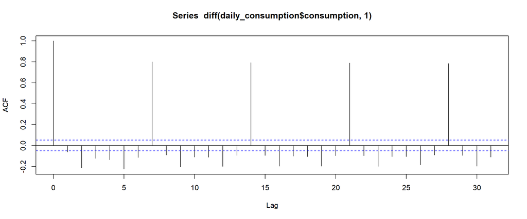

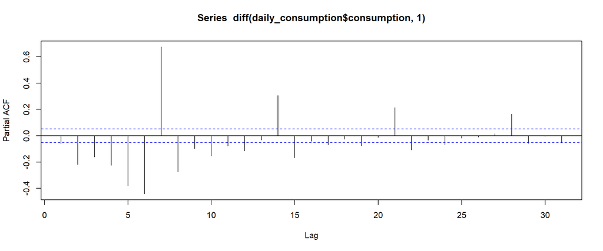

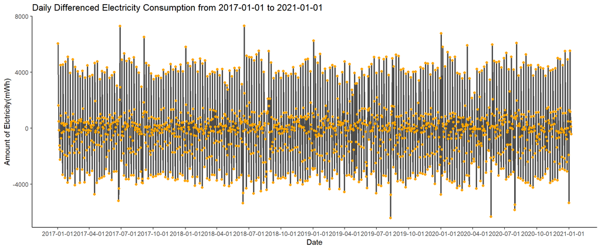

```
##
## #######################
## # KPSS Unit Root Test #
## #######################
##
## Test is of type: mu with 7 lags.
##
## Value of test-statistic is: 0.0101
##
## Critical value for a significance level of:
##                 10pct  5pct 2.5pct  1pct
## critical values 0.347 0.463  0.574 0.739
```

## **2. ARIMA Study and Forecasting**

In ARIMA modeling, the model is applied to some statistical techniques to be explained under some topics, which are autoregression, differencing, and moving average. These are applied at some lags called (p,d,q) corresponding the lag values for autoregression, differencing, and moving average, respectively. Also, ARIMA modeling has seasonal ARIMA (P,D,Q) corresponding autoregression, differencing, and moving average of seasonal variables, respectively.

Let’s find the best model by auto.arima() function and develop it by applying seasonal ARIMA and calculate the WMAPE of forecasted values:

```
##      Point Forecast      Lo 80     Hi 80      Lo 95    Hi 95
## 1470      -515.1773 -2494.3698 1464.0153 -3542.0910 2511.737
## 1471      -909.8322 -2895.0130 1075.3485 -3945.9042 2126.240
## 1472      2861.4433   868.2096 4854.6771  -186.9447 5909.831
## 1473      1081.4762 -1000.5519 3163.5043 -2102.7110 4265.663
## 1474     -1275.1076 -3360.2277  810.0125 -4464.0237 1913.808
## 1475       668.1166 -1421.1464 2757.3796 -2527.1354 3863.369
## 1476      2011.7043   -87.6354 4111.0440 -1198.9587 5222.367
## 1477     -1411.6974 -3682.2328  858.8381 -4884.1817 2060.787
## 1478     -1482.4791 -3755.1626  790.2045 -4958.2486 1993.290
## 1479      1752.3100  -520.4911 4025.1110 -1723.6393 5228.259
## 1480       635.9268 -1649.7108 2921.5644 -2859.6542 4131.508
## 1481     -2012.7832 -4299.9200  274.3536 -5510.6571 1485.091
## 1482       382.3220 -1905.4805 2670.1246 -3116.5700 3881.214
## 1483      1897.9949  -392.3237 4188.3135 -1604.7452 5400.735
## 1484     -1198.8200 -3489.4321 1091.7921 -4702.0089 2304.369
## 1485     -1377.5399 -3668.1748  913.0949 -4880.7637 2125.684
```

```
## [1] 26086.32
```

```
## [1] 26128.66
```

```
## [1] 25755.39
```

```
## [1] 25808.31
```

Point forecasts column is the forecasted values of the difference between consecutive days, i.e. 1-day lag difference forecasts of daily electricity consumption values. Also, the model is improved by adding seasonal ARIMA to what auto.arima() has found and the forecasted values are calculated with this improved algorithm, which has better AIC and BIC values. AIC and BIC values are shown at the below of the forecasts in the order of AIC & BIC values of auto.arima() model and AIC & BIC values of seasonal ARIMA added version. As we can see, the seasonal ARIMA values are better than what auto.arima() found. After forecasting the difference values, I calculated daily consumption values by adding difference values consecutively to the last consumption value. Also, I have checked the WMAPE values with exact values gotten from EPIAS and showed the results below:

```
##   n     mean sd        bias       mape      mad      wmape
## 1 1 34781.56 NA -0.04534476 0.04534476 1577.161 0.04534476
##   n    mean sd       bias       mape      mad      wmape
## 1 2 31841.9 NA -0.1132781 0.05663904 1803.495 0.05663904
##   n     mean sd        bias       mape      mad      wmape
## 1 3 36431.46 NA -0.05157275 0.01719092 626.2903 0.01719092
##   n     mean sd        bias       mape      mad      wmape
## 1 4 36897.99 NA -0.06758677 0.01689669 623.4541 0.01689669
##   n     mean sd        bias        mape      mad       wmape
## 1 5 37409.87 NA -0.01889429 0.003778857 141.3666 0.003778857
##   n     mean sd        bias        mape      mad       wmape
## 1 6 38056.05 NA -0.01914982 0.003191636 121.4611 0.003191636
##   n     mean sd        bias        mape      mad       wmape
## 1 7 38170.38 NA -0.06880051 0.009828644 375.1631 0.009828644
##   n     mean sd       bias      mape     mad     wmape
## 1 8 35667.35 NA -0.1042264 0.0130283 464.685 0.0130283
##   n     mean sd     bias       mape     mad      wmape
## 1 9 32557.96 NA -0.16415 0.01823889 593.821 0.01823889
##    n     mean sd        bias        mape     mad       wmape
## 1 10 38447.89 NA -0.03138715 0.003138715 120.677 0.003138715
##    n     mean sd        bias        mape      mad       wmape
## 1 11 39723.73 NA -0.01426981 0.001297256 51.53184 0.001297256
##    n     mean sd      bias        mape      mad       wmape
## 1 12 39960.92 NA 0.0421192 0.003509933 140.2602 0.003509933
##    n     mean sd       bias        mape      mad       wmape
## 1 13 39791.07 NA 0.02842207 0.002186313 86.99574 0.002186313
##    n     mean sd        bias        mape      mad       wmape
## 1 14 38902.97 NA -0.04254542 0.003038959 118.2245 0.003038959
```

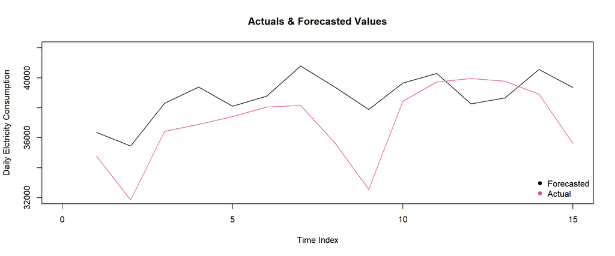

As a result, the weighted MAPE and MAPE results seem useful and are small which is useful for us to make predictions with small errors.